# Main Analysis for revision

Seonjoo Lee

2021-10-22

# Main Analysis

- Primary hypotheses were tested using power atlas, windowsize=30, omega=1, gamma=1.

## Sample size description

```r
X1.dat=datmerge_285(var='X1')%>%
#  mutate(numvol_cat=ifelse(rs.numvol==285,'10min','<10min')) %>%
  filter(is.na(rs.numvol)==FALSE |  is.na(task.numvol)==FALSE) %>%
  mutate(img_group=ifelse( is.na(rs.numvol)==FALSE &  is.na(task.numvol)==FALSE, 'Both',
                           ifelse(  is.na(rs.numvol)==FALSE &  is.na(task.numvol)==TRUE, 'rest Only', 'MatReas Only')))
```

## Table1. All n=386

- Initially, 523 participants in the sample.
- After quality check, n=386 participants were included. # Table1. Descriptive Tables {.tabset}

```r
summary(tableby(~Age+Education+Gender+NARTIQ+
                 NPSpeed_attention+NPReasoning+NPMemory+NPVocab+
                 WAIS3matRAW+MatReas_medianCorRT+MatReas_medianCorRT.log+
                  MatReas_NumCor+
                rs.Global_wocerebellum + task.Global_wocerebellum,
               numeric.simplify=TRUE,numeric.stats='meansd',
               X1.dat))
```

|  | Overall (N=386) |
| --- | --- |
| **Age** | 52.769 (17.039) |
| **Education** | 16.236 (2.335) |
| **Gender** |  |
| F | 215 (55.7%) |
| M | 171 (44.3%) |
| **NARTIQ** | 117.083 (8.642) |
| **NPSpeed_attention** | 0.042 (0.839) |
| **NPReasoning** | 0.066 (0.819) |
| **NPMemory** | 0.036 (0.951) |
| **NPVocab** | 0.046 (0.894) |
| **WAIS3matRAW** | 17.057 (5.150) |
| **MatReas_medianCorRT** | 21110.186 (10643.652) |
| **MatReas_medianCorRT.log** | 9.851 (0.498) |
| **MatReas_NumCor** | 6.318 (3.446) |
| **rs.Global_wocerebellum** | 0.096 (0.004) |
| **task.Global_wocerebellum** | 0.090 (0.005) |

```r
# summary(tableby(~Age+Education+Gender+NARTIQ+
#                  NPSpeed_attention+NPReasoning+NPMemory+NPVocab+
#                  WAIS3matRAW+MatReas_medianCorRT+MatReas_medianCorRT.log+
#                   MatReas_NumCor+
#                 rs.Global_wocerebellum + task.Global_wocerebellum,
#                numeric.simplify=TRUE,
#                X1.dat))
```

## Supplementary Table1. Resting vs. task

```r
a1=summary(tableby(~Age+Education+Gender+NARTIQ+
                 NPSpeed_attention+NPReasoning+NPMemory+NPVocab+
                 WAIS3matRAW+MatReas_medianCorRT+MatReas_NumCor+
                rs.Global_wocerebellum + task.Global_wocerebellum,
               numeric.simplify=TRUE,numeric.stats='meansd',
               X1.dat %>% filter(is.na(rs.numvol)==FALSE))) %>%
  data.frame() %>%
  left_join(.,
            summary(tableby(~Age+Education+Gender+NARTIQ+
                 NPSpeed_attention+NPReasoning+NPMemory+NPVocab+
                 WAIS3matRAW+MatReas_medianCorRT+MatReas_NumCor+
                rs.Global_wocerebellum + task.Global_wocerebellum,
               numeric.simplify=TRUE,numeric.stats='meansd',
               X1.dat %>% filter(is.na(task.numvol)==FALSE)))%>%
  data.frame())
names(a1)<-c('Variables','resting, n=279','taskfmri, n=294')
a1$Variables=gsub('[**]','',a1$Variables);a1$Variables=gsub('&nbsp;','',a1$Variables)
kable(a1) %>% kable_classic(full=F)
```

| Variables | resting, n=279 | taskfmri, n=294 |
| --- | --- | --- |
| Age | 53.573 (16.835) | 51.133 (17.037) |
| Education | 16.222 (2.354) | 16.180 (2.370) |
| Gender |  |  |
| F | 159 (57.0%) | 160 (54.4%) |
| M | 120 (43.0%) | 134 (45.6%) |
| NARTIQ | 117.419 (8.702) | 116.319 (8.979) |
| NPSpeed_attention | 0.050 (0.815) | 0.065 (0.835) |
| NPReasoning | 0.016 (0.793) | 0.114 (0.823) |
| NPMemory | 0.015 (0.960) | 0.060 (0.935) |
| NPVocab | 0.068 (0.901) | -0.022 (0.926) |
| WAIS3matRAW | 16.906 (5.065) | 17.277 (5.066) |
| MatReas_medianCorRT | 21795.146 (10427.363) | 21126.998 (10696.831) |
| MatReas_NumCor | 6.417 (3.332) | 6.467 (3.386) |
| rs.Global_wocerebellum | 0.096 (0.004) | 0.096 (0.004) |
| task.Global_wocerebellum | 0.090 (0.005) | 0.090 (0.005) |

## Supplementary Table2. By group comparison

```r
summary(tableby(img_group~Age+Education+Gender+NARTIQ+
                 NPSpeed_attention+NPReasoning+NPMemory+NPVocab+
                 WAIS3matRAW+MatReas_medianCorRT+MatReas_NumCor+
                rs.Global_wocerebellum + task.Global_wocerebellum,
               numeric.simplify=TRUE,numeric.stats='meansd',X1.dat))
```

|  | Both (N=187) | MatReas Only (N=107) | rest Only (N=92) | Total (N=386) | p value |
| --- | --- | --- | --- | --- | --- |
| **Age** | 51.396 (16.828) | 50.673 (17.467) | 58.000 (16.045) | 52.769 (17.039) | 0.003 |
| **Education** | 16.128 (2.415) | 16.271 (2.297) | 16.413 (2.224) | 16.236 (2.335) | 0.623 |
| **Gender** |  |  |  |  | 0.573 |
| F | 104 (55.6%) | 56 (52.3%) | 55 (59.8%) | 215 (55.7%) |  |
| M | 83 (44.4%) | 51 (47.7%) | 37 (40.2%) | 171 (44.3%) |  |
| **NARTIQ** | 116.378 (9.281) | 116.215 (8.465) | 119.607 (6.887) | 117.083 (8.642) | 0.007 |
| **NPSpeed_attention** | 0.088 (0.797) | 0.024 (0.901) | -0.029 (0.850) | 0.042 (0.839) | 0.526 |
| **NPReasoning** | 0.067 (0.792) | 0.196 (0.872) | -0.087 (0.790) | 0.066 (0.819) | 0.051 |
| **NPMemory** | 0.042 (0.941) | 0.093 (0.927) | -0.039 (1.001) | 0.036 (0.951) | 0.620 |
| **NPVocab** | -0.028 (0.955) | -0.011 (0.879) | 0.264 (0.747) | 0.046 (0.894) | 0.027 |
| **WAIS3matRAW** | 17.177 (4.896) | 17.453 (5.370) | 16.359 (5.377) | 17.057 (5.150) | 0.299 |
| **MatReas_medianCorRT** | 21936.005 (10468.598) | 19659.681 (10999.195) | 20954.532 (10306.154) | 21110.186 (10643.652) | 0.222 |
| **MatReas_NumCor** | 6.665 (3.203) | 6.108 (3.685) | 4.935 (3.741) | 6.318 (3.446) | 0.026 |
| **rs.Global_wocerebellum** | 0.096 (0.004) | NA | 0.096 (0.005) | 0.096 (0.004) |  |
| **task.Global_wocerebellum** | 0.090 (0.005) | 0.090 (0.005) | NA | 0.090 (0.005) |  |

```r
# summary(tableby(img_group~Age+Education+Gender+NARTIQ+
#                  NPSpeed_attention+NPReasoning+NPMemory+NPVocab+
#                  WAIS3matRAW+MatReas_medianCorRT+MatReas_NumCor+
#                 rs.Global_wocerebellum + task.Global_wocerebellum,
#                numeric.simplify=TRUE,X1.dat))

cat('Age');a = lsr::etaSquared( aov(lm(Age~img_group, X1.dat)), type = 3 );a/(1-a)
```

Age eta.sq eta.sq.part img_group 0.03080232 0.03080232

```r
cat('IQ');a = lsr::etaSquared( aov(lm(NARTIQ~img_group, X1.dat)) );a/(1-a)
```

IQ eta.sq eta.sq.part img_group 0.02664944 0.02664944

```r
cat('Vocab');a = lsr::etaSquared( aov(lm(NPVocab~img_group, X1.dat)), type = 3 );a/(1-a)
```

Vocab eta.sq eta.sq.part img_group 0.019044 0.019044

```r
cat('MatReas_NumCor');a = lsr::etaSquared( aov(lm(MatReas_NumCor~img_group, X1.dat)), type = 3 );a/(1-a)
```

MatReas_NumCor eta.sq eta.sq.part img_group 0.02338061 0.02338061

```r
cat('IQ, age adjusted');a = lsr::etaSquared( aov(lm(NARTIQ~img_group + Age, X1.dat)) );a/(1-a)
```

IQ, age adjusted eta.sq eta.sq.part img_group 0.01179919 0.01309662 Age 0.09124397 0.09390391

```r
cat('Vocab, age adjusted');a = lsr::etaSquared( aov(lm(NPVocab~img_group + Age, X1.dat)), type = 3 );a/(1-a)
```

Vocab, age adjusted eta.sq eta.sq.part img_group 0.007935802 0.008674776 Age 0.079565106 0.081203387

```r
cat('MatReas_NumCor, age adjusted');a = lsr::etaSquared( aov(lm(MatReas_NumCor~img_group + Age, X1.dat)), type = 3 );a/(1-a)
```

MatReas_NumCor, age adjusted eta.sq eta.sq.part img_group 0.01345318 0.01659103 Age 0.21513591 0.22127895

# Table2. Standardized regression coefficients with Age

## Linear Age

```r
nfvar.list = names(X1.dat)[c(18:29,31:42)]
cogvar.list = names(X1.dat)[c(7:10,6,12,17)]

xvar='Age'
tab2=do.call(rbind,lapply(nfvar.list, function(x){
  eval(parse(text=paste('fit<-lm(scale(',x,')~ scale(',xvar,'),X1.dat %>% filter(is.na(',x,')==FALSE & is.na(',xvar,')==FALSE))')))
  tmp=summary(fit)$coefficients
  re=data.frame(yvar=x, xvar=xvar,beta=tmp[,1], CI95=confint(fit),pval=tmp[,4])
  rownames(re)<-NULL
  return(re[2,])
  }))  %>%
  mutate(p.adjust=p.adjust(pval,method='BH'))

tab2%>%
#  filter(pval<0.05) %>%
  mutate(sig = paste(ifelse(pval<0.05,ifelse(pval<0.01, ifelse(pval<0.001,'***','**'),'*'),''),
         ifelse(p.adjust<0.05,'+',''),sep='')) %>%
  mutate(text = paste('[',round(CI95.2.5..,3), ',',round(CI95.97.5..,3),']',sig,sep='')) %>%
  dplyr::select(yvar, beta,text)%>%
  kable(.,full=F,digit=3) %>%
  kable_classic(.)
```

|  | yvar | beta | text |
| --- | --- | --- | --- |
| 2 | rs.Global_wocerebellum | -0.075 | [-0.193,0.043] |
| 21 | rs.AUD | -0.047 | [-0.165,0.071] |
| 22 | rs.CON | -0.013 | [-0.131,0.105] |
| 23 | rs.DAN | 0.044 | [-0.074,0.162] |
| 24 | rs.DMN_wocerebellum | -0.073 | [-0.191,0.045] |
| 25 | rs.FPN | -0.072 | [-0.19,0.046] |
| 26 | rs.MRN | -0.049 | [-0.167,0.07] |
| 27 | rs.SN | -0.035 | [-0.153,0.084] |
| 28 | rs.SMNh | -0.061 | [-0.179,0.057] |
| 29 | rs.SMNm | -0.166 | [-0.282,-0.049]** |
| 210 | rs.VAN | -0.017 | [-0.135,0.102] |
| 211 | rs.Visual | -0.049 | [-0.167,0.069] |
| 212 | task.Global_wocerebellum | 0.091 | [-0.023,0.206] |
| 213 | task.AUD | 0.076 | [-0.039,0.191] |
| 214 | task.CON | 0.102 | [-0.013,0.217] |
| 215 | task.DAN | 0.067 | [-0.047,0.182] |
| 216 | task.DMN_wocerebellum | 0.095 | [-0.019,0.21] |
| 217 | task.FPN | 0.109 | [-0.005,0.224] |
| 218 | task.MRN | 0.034 | [-0.081,0.15] |
| 219 | task.SN | 0.120 | [0.005,0.234]* |
| 220 | task.SMNh | 0.108 | [-0.007,0.222] |
| 221 | task.SMNm | 0.016 | [-0.099,0.131] |
| 222 | task.VAN | 0.073 | [-0.042,0.188] |
| 223 | task.Visual | 0.121 | [0.006,0.235]* |

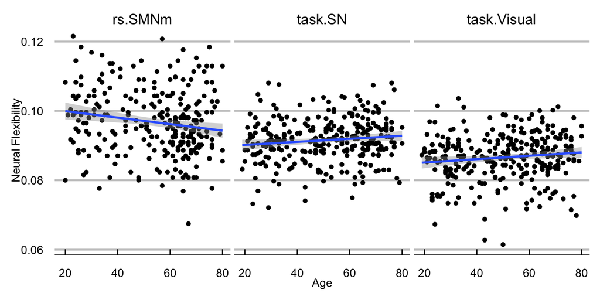

```r
tab2.fig = tab2 %>%
  filter(pval<0.05) %>%
  mutate(sig = paste(ifelse(pval<0.05,ifelse(pval<0.01, ifelse(pval<0.001,'***','**'),'*'),''),
         ifelse(p.adjust<0.05,'+',''),sep='')) %>%
  mutate(text = paste('beta=',round(beta,2),' [',round(CI95.2.5..,2), ',',round(CI95.97.5..,2),']',sig,sep=''))


X1.dat %>% select(Sub.ID,Age, tab2.fig$yvar) %>%
  melt(.,id=c('Sub.ID','Age'))  %>%
  ggplot(., aes(x=Age, y=value)) +
  geom_point() + facet_wrap(~variable, ncol=4)+
    stat_smooth(method='lm')+
  theme_economist_white(gray_bg=F) + theme(legend.position='bottom') +
  ylab('Neural Flexibility') +
  xlab('Age')
```

## Quadratic age

- None of the quadratic terms was significant.

```r
tab2=do.call(rbind,lapply(nfvar.list, function(x){
  eval(parse(text=paste('fit<-lm(scale(',x,')~ Agesq + scale(',xvar,'),X1.dat %>% filter(is.na(',x,')==FALSE & is.na(',xvar,')==FALSE) %>% mutate(Agesq = scale(Age)*scale(Age)))')))
  tmp=summary(fit)$coefficients
  re=data.frame(yvar=x, xvar=xvar,beta=tmp[,1], CI95=confint(fit),pval=tmp[,4])
  rownames(re)<-NULL
  return(re[2,])
  }))  %>%
  mutate(p.adjust=p.adjust(pval,method='BH'))

tab2%>%
#  filter(pval<0.05) %>%
  mutate(sig = paste(ifelse(pval<0.05,ifelse(pval<0.01, ifelse(pval<0.001,'***','**'),'*'),''),
         ifelse(p.adjust<0.05,'+',''),sep='')) %>%
  mutate(text = paste('[',round(CI95.2.5..,3), ',',round(CI95.97.5..,3),']',sig,sep='')) %>%
  dplyr::select(yvar, beta,text)%>%
  kable(.,full=F,digit=3) %>%
  kable_classic(.)
```

|  | yvar | beta | text |
| --- | --- | --- | --- |
| 2 | rs.Global_wocerebellum | -0.038 | [-0.18,0.104] |
| 21 | rs.AUD | 0.048 | [-0.094,0.191] |
| 22 | rs.CON | -0.004 | [-0.147,0.139] |
| 23 | rs.DAN | -0.045 | [-0.187,0.098] |
| 24 | rs.DMN_wocerebellum | -0.056 | [-0.198,0.086] |
| 25 | rs.FPN | 0.048 | [-0.094,0.19] |
| 26 | rs.MRN | 0.029 | [-0.114,0.171] |
| 27 | rs.SN | 0.006 | [-0.137,0.148] |
| 28 | rs.SMNh | 0.084 | [-0.058,0.226] |
| 29 | rs.SMNm | 0.068 | [-0.072,0.209] |
| 210 | rs.VAN | 0.027 | [-0.116,0.17] |
| 211 | rs.Visual | 0.017 | [-0.125,0.16] |
| 212 | task.Global_wocerebellum | -0.052 | [-0.185,0.081] |
| 213 | task.AUD | -0.030 | [-0.163,0.104] |
| 214 | task.CON | 0.012 | [-0.121,0.145] |
| 215 | task.DAN | 0.029 | [-0.104,0.162] |
| 216 | task.DMN_wocerebellum | -0.078 | [-0.21,0.055] |
| 217 | task.FPN | 0.001 | [-0.132,0.134] |
| 218 | task.MRN | -0.039 | [-0.173,0.094] |
| 219 | task.SN | -0.020 | [-0.152,0.113] |
| 220 | task.SMNh | 0.001 | [-0.132,0.134] |
| 221 | task.SMNm | 0.040 | [-0.093,0.174] |
| 222 | task.VAN | 0.035 | [-0.098,0.169] |
| 223 | task.Visual | 0.044 | [-0.088,0.177] |

## Age group

```r
X1.dat2 = X1.dat %>% mutate(AgeGroup = cut(Age,breaks=c(0,40,61, 100), right=FALSE) )
summary(tableby(AgeGroup ~ Age, X1.dat2))
```

|  | [0,40) (N=106) | [40,61) (N=106) | [61,100) (N=174) | Total (N=386) | p value |
| --- | --- | --- | --- | --- | --- |
| **Age** |  |  |  |  | < 0.001 |
| Mean (SD) | 28.896 (5.259) | 51.538 (5.707) | 68.063 (4.918) | 52.769 (17.039) |  |
| Range | 19.000 - 39.000 | 40.000 - 60.000 | 61.000 - 80.000 | 19.000 - 80.000 |  |

```r
tab2%>%
#  filter(pval<0.05) %>%
  mutate(sig = paste(ifelse(pval<0.05,ifelse(pval<0.01, ifelse(pval<0.001,'***','**'),'*'),''),
         ifelse(p.adjust<0.05,'+',''),sep='')) %>%
  dplyr::select(yvar,fval,pval,sig, p.adjust)%>%
  kable(.,full=F,digit=3) %>%
  kable_classic(.)
```

| yvar | fval | pval | sig | p.adjust |
| --- | --- | --- | --- | --- |
| rs.Global_wocerebellum | 1.999 | 0.137 |  | 0.582 |
| rs.AUD | 0.812 | 0.445 |  | 0.650 |
| rs.CON | 0.114 | 0.893 |  | 0.932 |
| rs.DAN | 0.778 | 0.460 |  | 0.650 |
| rs.DMN_wocerebellum | 2.401 | 0.093 |  | 0.582 |
| rs.FPN | 1.181 | 0.308 |  | 0.650 |
| rs.MRN | 1.741 | 0.177 |  | 0.582 |
| rs.SN | 1.571 | 0.210 |  | 0.582 |
| rs.SMNh | 0.375 | 0.688 |  | 0.765 |
| rs.SMNm | 4.876 | 0.008 | ** | 0.199 |
| rs.VAN | 0.051 | 0.950 |  | 0.950 |
| rs.Visual | 0.355 | 0.701 |  | 0.765 |
| task.Global_wocerebellum | 0.871 | 0.420 |  | 0.650 |
| task.AUD | 0.986 | 0.374 |  | 0.650 |
| task.CON | 1.222 | 0.296 |  | 0.650 |
| task.DAN | 0.594 | 0.553 |  | 0.737 |
| task.DMN_wocerebellum | 0.912 | 0.403 |  | 0.650 |
| task.FPN | 1.647 | 0.194 |  | 0.582 |
| task.MRN | 0.782 | 0.458 |  | 0.650 |
| task.SN | 1.529 | 0.218 |  | 0.582 |
| task.SMNh | 1.784 | 0.170 |  | 0.582 |
| task.SMNm | 0.390 | 0.677 |  | 0.765 |
| task.VAN | 0.535 | 0.586 |  | 0.740 |
| task.Visual | 2.029 | 0.133 |  | 0.582 |

```r
tab2=do.call(rbind,lapply(nfvar.list, function(x){
  eval(parse(text=paste('fit<-lm(scale(',x,')~ AgeGroup,
                        X1.dat2 %>% filter(is.na(',x,')==FALSE & is.na(',xvar,')==FALSE) )')))
  tmp=summary(fit)$coefficients
  re=data.frame(yvar=x, xvar=xvar,beta=tmp[,1], parameter=row.names(tmp),
                CI95=confint(fit),pval=tmp[,4])
  rownames(re)<-NULL
  return(re[2:3,])
  }))  %>%
  mutate(p.adjust=p.adjust(pval,method='BH'))

tab2%>%
  filter(pval<0.05) %>%
  mutate(sig = paste(ifelse(pval<0.05,ifelse(pval<0.01, ifelse(pval<0.001,'***','**'),'*'),''),
         ifelse(p.adjust<0.05,'+',''),sep='')) %>%
  mutate(text = paste('[',round(CI95.2.5..,3), ',',round(CI95.97.5..,3),']',sig,sep='')) %>%
  dplyr::select(yvar,parameter, beta,text)%>%
  kable(.,full=F,digit=3) %>%
  kable_classic(.)
```

|  | yvar | parameter | beta | text |
| --- | --- | --- | --- | --- |
| 39 | rs.SMNm | AgeGroup[61,100) | -0.435 | [-0.717,-0.153]** |

# Table3. Linear regression for cognitive outcomes with neural flexibility.

- All regression is controlled for age, sex, education

```r
do.call(rbind, lapply( cogvar.list, function(yvar){
do.call(rbind,lapply(nfvar.list, function(xvar){
  eval(parse(text=paste('fit<-lm(scale(',yvar,')~ scale(',xvar,') + Age + Gender + Education,X1.dat %>% filter(is.na(',xvar,')==FALSE & is.na(',yvar,')==FALSE))')))
  tmp=summary(fit)$coefficients
  re=data.frame(xvar=xvar, yvar=yvar,beta=tmp[,1], CI95=confint(fit),pval=tmp[,4])
  rownames(re)<-NULL
  return(re[2,])
  }))}))  %>%
  mutate(p.adjust=p.adjust(pval,method='BH')) %>%
  mutate(sig = paste(ifelse(pval<0.05,ifelse(pval<0.01, ifelse(pval<0.001,'***','**'),'*'),''),
         ifelse(p.adjust<0.05,'+',''),sep='')) %>%
  filter(pval<0.05) %>%
  mutate(text = paste('[',round(CI95.2.5..,3), ',',round(CI95.97.5..,3),']',sig,sep='')) %>%
  dplyr::select(yvar,xvar, beta,text) %>%
  kable(.,full=F,digit=3) %>%
  kable_classic(.)
```

|  | yvar | xvar | beta | text |
| --- | --- | --- | --- | --- |
| 2171 | NPReasoning | task.FPN | -0.116 | [-0.217,-0.016]* |
| 2154 | WAIS3matRAW | task.DAN | -0.113 | [-0.219,-0.006]* |
| 2174 | WAIS3matRAW | task.FPN | -0.155 | [-0.261,-0.049]** |
| 2119 | MatReas_NumCor | rs.Visual | 0.122 | [0.003,0.24]* |
| 2126 | MatReas_medianCorRT.log | task.Global_wocerebellum | -0.170 | [-0.281,-0.058]** |
| 2136 | MatReas_medianCorRT.log | task.AUD | -0.152 | [-0.264,-0.04]** |
| 2146 | MatReas_medianCorRT.log | task.CON | -0.171 | [-0.283,-0.059]** |
| 2156 | MatReas_medianCorRT.log | task.DAN | -0.115 | [-0.228,-0.003]* |
| 2166 | MatReas_medianCorRT.log | task.DMN_wocerebellum | -0.177 | [-0.288,-0.066]** |
| 2176 | MatReas_medianCorRT.log | task.FPN | -0.143 | [-0.255,-0.031]* |
| 2196 | MatReas_medianCorRT.log | task.SN | -0.148 | [-0.26,-0.035]* |
| 2206 | MatReas_medianCorRT.log | task.SMNh | -0.134 | [-0.247,-0.021]* |
| 2226 | MatReas_medianCorRT.log | task.VAN | -0.175 | [-0.287,-0.063]** |

# Table4. Moderation of cognitive Aging

## Continuous Age

```r
do.call(rbind, lapply( cogvar.list, function(yvar){
do.call(rbind,lapply(nfvar.list, function(xvar){
  eval(parse(text=paste('fit<-lm(scale(',yvar,')~ scale(',xvar,') * scale(Age) + Gender + Education,X1.dat %>% filter(is.na(',xvar,')==FALSE & is.na(',yvar,')==FALSE))')))
  tmp=summary(fit)$coefficients
  re=data.frame(xvar=xvar, yvar=yvar,beta=tmp[,1], CI95=confint(fit),pval=tmp[,4])
  rownames(re)<-NULL
  return(re[6,])
  }))}))  %>%
  mutate(p.adjust=p.adjust(pval,method='BH')) %>%
  mutate(sig = paste(ifelse(pval<0.05,ifelse(pval<0.01, ifelse(pval<0.001,'***','**'),'*'),''),
         ifelse(p.adjust<0.05,'+',''),sep='')) %>%
  filter(pval<0.05) %>%
  mutate(text = paste('[',round(CI95.2.5..,3), ',',round(CI95.97.5..,3),']',sig,sep='')) %>%
  dplyr::select(yvar,xvar, beta,text) %>%
  kable(.,full=F,digit=3) %>%
  kable_classic(.)
```

|  | yvar | xvar | beta | text |
| --- | --- | --- | --- | --- |
| 6196 | MatReas_medianCorRT.log | task.SN | 0.119 | [0.009,0.228]* |
| 6236 | MatReas_medianCorRT.log | task.Visual | 0.138 | [0.024,0.251]* |

## Categorical Age

```r
do.call(rbind, lapply( cogvar.list, function(yvar){
do.call(rbind,lapply(nfvar.list, function(xvar){
  eval(parse(text=paste('fit<-lm(scale(',yvar,')~ scale(',xvar,') * AgeGroup + Gender + Education,X1.dat2 %>% filter(is.na(',xvar,')==FALSE & is.na(',yvar,')==FALSE))')))
  tmp=anova(fit)
#  print(tmp)
  re=data.frame(xvar=xvar, yvar=yvar,Fval=tmp[5,4],pval=tmp[5,5])
  rownames(re)<-NULL
  return(re)
  }))}))  %>%
  mutate(p.adjust=p.adjust(pval,method='BH')) %>%
  mutate(sig = paste(ifelse(pval<0.05,ifelse(pval<0.01, ifelse(pval<0.001,'***','**'),'*'),''),
         ifelse(p.adjust<0.05,'+',''),sep='')) %>%
  filter(pval<0.05) %>%
  dplyr::select(yvar,xvar, Fval,pval, sig, p.adjust) %>%
  kable(.,full=F,digit=3) %>%
  kable_classic(.)
```

```r
do.call(rbind, lapply( cogvar.list, function(yvar){
do.call(rbind,lapply(nfvar.list, function(xvar){
  eval(parse(text=paste('fit<-lm(scale(',yvar,')~ scale(',xvar,') * AgeGroup + Gender + Education,X1.dat2 %>% filter(is.na(',xvar,')==FALSE & is.na(',yvar,')==FALSE))')))
  tmp=summary(fit)$coefficients
  re=data.frame(xvar=xvar, yvar=yvar,parameter=rownames(tmp),
                beta=tmp[,1], CI95=confint(fit),pval=tmp[,4])
  rownames(re)<-NULL
#  print(re)
  return(re[7:8,])
  }))}))  %>%
  mutate(p.adjust=p.adjust(pval,method='BH')) %>%
  mutate(sig = paste(ifelse(pval<0.05,ifelse(pval<0.01, ifelse(pval<0.001,'***','**'),'*'),''),
         ifelse(p.adjust<0.05,'+',''),sep='')) %>%
  filter(pval<0.05) %>%
  mutate(text = paste('[',round(CI95.2.5..,3), ',',round(CI95.97.5..,3),']',sig,sep='')) %>%
  dplyr::select(yvar,xvar, parameter,beta,text) %>%
  kable(.,full=F,digit=3) %>%
  kable_classic(.)
```

|  | yvar | xvar | parameter | beta | text |
| --- | --- | --- | --- | --- | --- |
| 712 | NPSpeed_attention | task.Global_wocerebellum | scale(task.Global_wocerebellum):AgeGroup[40,61) | -0.264 | [-0.488,-0.039]* |
| 714 | NPSpeed_attention | task.CON | scale(task.CON):AgeGroup[40,61) | -0.232 | [-0.459,-0.005]* |
| 716 | NPSpeed_attention | task.DMN_wocerebellum | scale(task.DMN_wocerebellum):AgeGroup[40,61) | -0.236 | [-0.463,-0.009]* |
| 717 | NPSpeed_attention | task.FPN | scale(task.FPN):AgeGroup[40,61) | -0.239 | [-0.472,-0.007]* |
| 721 | NPSpeed_attention | task.SMNm | scale(task.SMNm):AgeGroup[40,61) | -0.369 | [-0.607,-0.131]** |
| 821 | NPSpeed_attention | task.SMNm | scale(task.SMNm):AgeGroup[61,100) | -0.270 | [-0.512,-0.029]* |
| 8211 | NPReasoning | task.SMNm | scale(task.SMNm):AgeGroup[61,100) | -0.293 | [-0.547,-0.04]* |
| 7114 | NPVocab | rs.AUD | scale(rs.AUD):AgeGroup[40,61) | -0.395 | [-0.655,-0.135]** |
| 763 | NPVocab | rs.MRN | scale(rs.MRN):AgeGroup[40,61) | -0.309 | [-0.596,-0.022]* |
| 8196 | MatReas_medianCorRT.log | task.SN | scale(task.SN):AgeGroup[61,100) | 0.270 | [0.002,0.537]* |
| 8236 | MatReas_medianCorRT.log | task.Visual | scale(task.Visual):AgeGroup[61,100) | 0.321 | [0.037,0.605]* |

# Supplementary Table 2. Paired t-test

- n=187 participants

```r
nfdata2=  X1.dat %>% filter(img_group=='Both') %>%
  arrange(Sub.ID)## 293

networks=c('Global_wocerebellum','AUD','CON','DMN_wocerebellum','DAN','FPN','SN','SMNh','SMNm','VAN','Visual')

for (j in networks){
      eval(parse(text=paste('nfdata2$chng.', j ,'= NA',sep='')))
    eval(parse(text=paste('nfdata2$chng.', j, '=nfdata2$task.',j,'-nfdata2$rs.',j,sep='')))

}


do.call(rbind, lapply(networks,function(j){
    mycol=paste(c('task','rs'),j,sep='.')
    tmpdat = nfdata2[,c('Sub.ID',mycol)] %>% melt(.,id='Sub.ID')
    eval(parse(text=paste('fit=t.test(nfdata2$task.',j,',nfdata2$rs.',j,',paired=TRUE)',sep='')))
    eval(parse(text=paste('ds=effectsize::cohens_d(nfdata2$task.',j,',nfdata2$rs.',j,',paired=TRUE)',sep='')))

    a = (data.frame(networks=j,diff=fit$estimate,lci=fit$conf.int[1],uci=fit$conf.int[2],
               t=fit$statistic,df=fit$parameter,pvalue=fit$p.value,data.frame(ds)))
    return(a)
    })) %>%
  dplyr::select(-CI) %>%
  mutate(p.adjust=p.adjust(pvalue, method='BH')) %>%
  mutate(sig = paste(ifelse(pvalue<0.05,
                             ifelse(pvalue<0.01,
                                    ifelse(pvalue<0.001,'***','**'),'*'),''),
                     ifelse(p.adjust<0.05,'+',''),sep='')) %>%
  mutate(text=paste('[',round(lci,3),',',round(uci,3),']', sig))  %>%
  select(networks, diff, text,Cohens_d) %>%
  kable(., digits=3) %>%
  kable_classic(.)
```

|  | networks | diff | text | Cohens_d |
| --- | --- | --- | --- | --- |
| mean of the differences | Global_wocerebellum | -0.006 | [ -0.007 , -0.005 ] ***+ | -0.913 |
| mean of the differences1 | AUD | -0.006 | [ -0.007 , -0.004 ] ***+ | -0.648 |
| mean of the differences2 | CON | -0.005 | [ -0.006 , -0.004 ] ***+ | -0.600 |
| mean of the differences3 | DMN_wocerebellum | -0.006 | [ -0.006 , -0.005 ] ***+ | -0.854 |
| mean of the differences4 | DAN | -0.010 | [ -0.012 , -0.009 ] ***+ | -1.036 |
| mean of the differences5 | FPN | -0.008 | [ -0.009 , -0.007 ] ***+ | -0.992 |
| mean of the differences6 | SN | -0.006 | [ -0.007 , -0.005 ] ***+ | -0.776 |
| mean of the differences7 | SMNh | -0.005 | [ -0.006 , -0.004 ] ***+ | -0.630 |
| mean of the differences8 | SMNm | -0.004 | [ -0.006 , -0.002 ] ***+ | -0.287 |
| mean of the differences9 | VAN | -0.005 | [ -0.006 , -0.004 ] ***+ | -0.562 |
| mean of the differences10 | Visual | -0.009 | [ -0.01 , -0.008 ] ***+ | -0.997 |

- Variance comparison between resting and task

```r
do.call(rbind, lapply(networks,function(j){
    mycol=paste(c('task','rs'),j,sep='.')
    tmpdat = nfdata2[,c('Sub.ID',mycol)] %>%
      melt(.,id='Sub.ID') %>%
      mutate(variable=factor(variable,levels=paste(c('rs','task'),j,sep='.')))
    vardesc=tmpdat %>% group_by(variable) %>% summarise(sd = sd(value)) %>%
      mutate(variable=gsub(j,'',variable)) %>% reshape2::dcast(., .~variable,mean)
    fit=var.test(value ~ variable, tmpdat,alternative="two.sided")

    a = (data.frame(networks=j,vardesc,var.ratio = fit$estimate, ci=t(fit$conf.int),f=fit$statistic,df=t(fit$parameter),pvalue=fit$p.value))
    return(a)
    })) %>%
  mutate(p.adjust=p.adjust(pvalue, method='BH')) %>%
  mutate(sig = paste(ifelse(pvalue<0.05,
                             ifelse(pvalue<0.01,
                                    ifelse(pvalue<0.001,'***','**'),'*'),''),
                     ifelse(p.adjust<0.05,'+',''),sep='')) %>%
  mutate(text=paste('[',round(ci.1,3),',',round(ci.2,3),']', sig))  %>%
  select(networks, rs., task., var.ratio,text)%>%
  kable(., digits=4) %>%
  kable_classic(.)
```

|  | networks | rs. | task. | var.ratio | text |
| --- | --- | --- | --- | --- | --- |
| ratio of variances | Global_wocerebellum | 0.0042 | 0.0049 | 0.7523 | [ 0.564 , 1.004 ] |
| ratio of variances1 | AUD | 0.0061 | 0.0070 | 0.7570 | [ 0.567 , 1.01 ] |
| ratio of variances2 | CON | 0.0057 | 0.0063 | 0.8044 | [ 0.603 , 1.073 ] |
| ratio of variances3 | DMN_wocerebellum | 0.0044 | 0.0049 | 0.7873 | [ 0.59 , 1.05 ] |
| ratio of variances4 | DAN | 0.0066 | 0.0079 | 0.7035 | [ 0.527 , 0.939 ] * |
| ratio of variances5 | FPN | 0.0051 | 0.0063 | 0.6383 | [ 0.478 , 0.852 ] **+ |
| ratio of variances6 | SN | 0.0055 | 0.0061 | 0.7965 | [ 0.597 , 1.063 ] |
| ratio of variances7 | SMNh | 0.0056 | 0.0059 | 0.9036 | [ 0.677 , 1.206 ] |
| ratio of variances8 | SMNm | 0.0097 | 0.0091 | 1.1187 | [ 0.839 , 1.493 ] |
| ratio of variances9 | VAN | 0.0069 | 0.0071 | 0.9666 | [ 0.724 , 1.29 ] |
| ratio of variances10 | Visual | 0.0055 | 0.0073 | 0.5801 | [ 0.435 , 0.774 ] ***+ |

- Figure

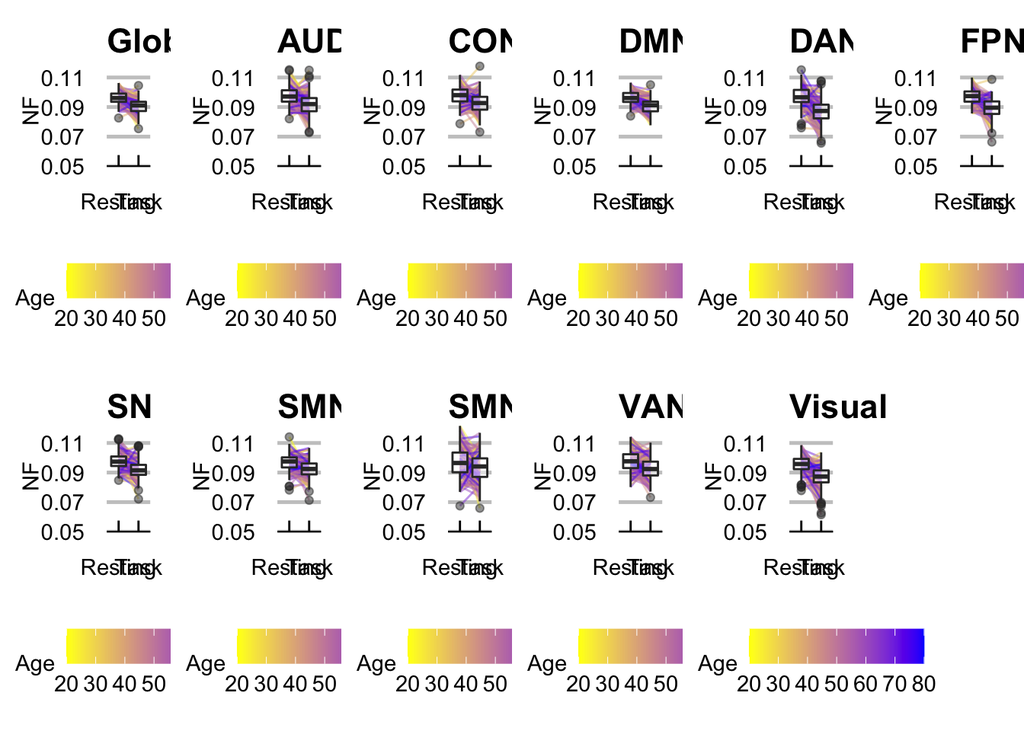

```r
sig_pairdtests2 <-function(nname){
  long = nfdata2[, c('Sub.ID','Age',paste('rs.',nname,sep=''),paste('task.',nname,sep=''))] %>%
    melt(.,id=c('Sub.ID','Age')) %>% rename(group=variable) %>%
    arrange(Sub.ID, group)
  long$group = gsub('_wocerebellum','',long$group)

  re.table = long %>%
    t_test(value ~ group, paired = TRUE) %>%
    mutate(.y.=nname) %>%
    add_significance() %>% data.frame(.)

  re.fig = ggplot(long, aes(x=group, y=value)) +
    geom_line(aes(group=Sub.ID,colour=Age),alpha=0.5) +
#    geom_point() +
    geom_boxplot(alpha=0.5) +
    # scale_colour_gradientn(colours = rev(rainbow(10,end=0.7))) +
    scale_colour_gradient(low = "yellow", high = "blue") +
    theme_economist_white(gray_bg = FALSE) +
    stat_compare_means(method = "t.test", paired=TRUE,
                       label.y = 0.17) +
    ylab("NF") + xlab('') +
    theme(legend.position="bottom",
          legend.text=element_text(size=11)) +
    scale_y_continuous(limits=c(0.05, 0.125), expand = c(0, 0)) +
    scale_x_discrete(labels = c("Resting", "Task")) +
    ggtitle(nname)

  return(list(re.table, re.fig) )
}

sig_nfvar.list = networks
sig_re = lapply(sig_nfvar.list, sig_pairdtests2)

do.call(grid.arrange, c(lapply(sig_re, function(x)x[[2]]), ncol=6))
```

```r
png("./Fig1.png", width=4000, height=2400, res=300)
do.call(grid.arrange, c(lapply(sig_re, function(x)x[[2]]), ncol=6))
dev.off()#saves
```

```r
long = nfdata2[, c('Sub.ID','Age',paste('rs.',sig_nfvar.list,sep=''),paste('task.',sig_nfvar.list,sep=''))] %>%
    melt(.,id=c('Sub.ID','Age')) %>% rename(group=variable) %>%
    arrange(Sub.ID, group)
long$group = gsub('_wocerebellum','',long$group)
long$scan.con = factor(unlist(lapply(long$group,function(x)strsplit(x,'[.]')[[1]][1])), levels=c('rs','task'),labels=c('Resting','Task'))

long$Network = relevel(factor(unlist(lapply(long$group,function(x)strsplit(x,'[.]')[[1]][2]))), ref='Global')

fig=ggplot(long, aes(x=scan.con, y=value)) +
    geom_line(aes(group=Sub.ID,colour=Age),alpha=0.5) +
    facet_wrap(~Network,nrow=2)+
#    geom_point() +
    geom_boxplot(alpha=0.5) +
    # scale_colour_gradientn(colours = rev(rainbow(10,end=0.7))) +
    scale_colour_gradient(low = "yellow", high = "blue") +
    theme_minimal()+
    #theme_economist_white(gray_bg = FALSE) +
    ylab("NF") + xlab('') +
    theme(legend.position=c(0.92,0.2),
          legend.text=element_text(size=11),
          strip.text.x = element_text(size = 15, face='bold'))

png("./Fig2_paired_ttest.png", width=2400, height=1800, res=300)
fig
dev.off()#saves
```

# Supplementary Table 3. Correlation between rsfMRI-taskfMRI neural flexibility with age, IQ and cognitions.

- Correlation with Age

```r
networks.list=paste('chng',networks,sep='.')
do.call(rbind, lapply( 'Age', function(xvar){
do.call(rbind,lapply(networks.list, function(yvar){
  eval(parse(text=paste('fit<-lm(scale(',yvar,')~ scale(',xvar,'),nfdata2 %>% filter(is.na(',xvar,')==FALSE & is.na(',yvar,')==FALSE))')))
  tmp=summary(fit)$coefficients
  re=data.frame(xvar=xvar, yvar=yvar,beta=tmp[,1], CI95=confint(fit),pval=tmp[,4])
  rownames(re)<-NULL
  return(re[2,])
  }))}))  %>%
  mutate(p.adjust=p.adjust(pval,method='BH')) %>%
  mutate(sig = paste(ifelse(pval<0.05,ifelse(pval<0.01, ifelse(pval<0.001,'***','**'),'*'),''),
         ifelse(p.adjust<0.05,'+',''),sep='')) %>%
  filter(pval<0.1) %>%
  mutate(text = paste('[',round(CI95.2.5..,3), ',',round(CI95.97.5..,3),']',sig,sep='')) %>%
  dplyr::select(yvar,xvar, beta,pval,text) %>%
  kable(.,full=F,digit=3) %>%
  kable_classic(.)
```

|  | yvar | xvar | beta | pval | text |
| --- | --- | --- | --- | --- | --- |
| 2 | chng.Global_wocerebellum | Age | 0.127 | 0.082 | [-0.016,0.271] |
| 23 | chng.DMN_wocerebellum | Age | 0.122 | 0.096 | [-0.022,0.266] |
| 25 | chng.FPN | Age | 0.135 | 0.065 | [-0.008,0.279] |
| 27 | chng.SMNh | Age | 0.141 | 0.054 | [-0.002,0.285] |

- Correlation with IQ

```r
networks.list=paste('chng',networks,sep='.')
do.call(rbind, lapply( 'NARTIQ', function(xvar){
do.call(rbind,lapply(networks.list, function(yvar){
  eval(parse(text=paste('fit<-lm(scale(',yvar,')~ scale(',xvar,'),nfdata2 %>% filter(is.na(',xvar,')==FALSE & is.na(',yvar,')==FALSE))')))
  tmp=summary(fit)$coefficients
  re=data.frame(xvar=xvar, yvar=yvar,beta=tmp[,1], CI95=confint(fit),pval=tmp[,4])
  rownames(re)<-NULL
  return(re[2,])
  }))}))  %>%
  mutate(p.adjust=p.adjust(pval,method='BH')) %>%
  mutate(sig = paste(ifelse(pval<0.05,ifelse(pval<0.01, ifelse(pval<0.001,'***','**'),'*'),''),
         ifelse(p.adjust<0.05,'+',''),sep='')) %>%
  filter(pval<0.25) %>%
  mutate(text = paste('[',round(CI95.2.5..,3), ',',round(CI95.97.5..,3),']',sig,sep='')) %>%
  dplyr::select(yvar,xvar, beta,pval,text) %>%
  kable(.,full=F,digit=3) %>%
  kable_classic(.)
```

|  | yvar | xvar | beta | pval | text |
| --- | --- | --- | --- | --- | --- |
| 24 | chng.DAN | NARTIQ | 0.088 | 0.229 | [-0.056,0.233] |
| 28 | chng.SMNm | NARTIQ | 0.085 | 0.248 | [-0.06,0.229] |

- All models adjusted for age, gender and education.

```r
for (j in networks){
      eval(parse(text=paste('nfdata2$chng.', j ,'= NA',sep='')))
    eval(parse(text=paste('nfdata2$chng.', j, '=nfdata2$task.',j,'-nfdata2$rs.',j,sep='')))

}
networks.list=paste('chng',networks,sep='.')
do.call(rbind, lapply( cogvar.list, function(yvar){
do.call(rbind,lapply(networks.list, function(xvar){
  eval(parse(text=paste('fit<-lm(scale(',yvar,')~ scale(',xvar,') + Age + Gender + Education,nfdata2 %>% filter(is.na(',xvar,')==FALSE & is.na(',yvar,')==FALSE))')))
  tmp=summary(fit)$coefficients
  re=data.frame(xvar=xvar, yvar=yvar,beta=tmp[,1], CI95=confint(fit),pval=tmp[,4])
  rownames(re)<-NULL
  return(re[2,])
  }))}))  %>%
  mutate(p.adjust=p.adjust(pval,method='BH')) %>%
  mutate(sig = paste(ifelse(pval<0.05,ifelse(pval<0.01, ifelse(pval<0.001,'***','**'),'*'),''),
         ifelse(p.adjust<0.05,'+',''),sep='')) %>%
  filter(pval<0.05) %>%
  mutate(text = paste('[',round(CI95.2.5..,3), ',',round(CI95.97.5..,3),']',sig,sep='')) %>%
  dplyr::select(yvar,xvar, beta,pval,text) %>%
  kable(.,full=F,digit=3) %>%
  kable_classic(.)
```

|  | yvar | xvar | beta | pval | text |
| --- | --- | --- | --- | --- | --- |
| 25 | NPSpeed_attention | chng.FPN | -0.124 | 0.048 | [-0.247,-0.001]* |
| 254 | WAIS3matRAW | chng.FPN | -0.135 | 0.046 | [-0.267,-0.003]* |
| 226 | MatReas_medianCorRT.log | chng.CON | -0.138 | 0.043 | [-0.271,-0.004]* |
| 296 | MatReas_medianCorRT.log | chng.VAN | -0.154 | 0.023 | [-0.287,-0.021]* |

```r
nfdata2 %>% select(Sub.ID,chng.gnf,chng.DMN,chng.Visual,Age, MatReas_medianCorRT.log) %>%
  melt(.,id=c('Sub.ID','Age','MatReas_medianCorRT.log')) %>%
  mutate(variable =factor(variable, levels=c('chng.gnf','chng.DMN','chng.Visual'),
                          labels=c('Global', 'DMN','Visual Network'))) %>%
  ggplot(., aes(x=value, y=MatReas_medianCorRT.log)) +
  geom_point(aes(color=Age)) + facet_wrap(~variable, ncol=3)+
    stat_smooth(method='lm')+
    scale_color_gradientn(colours =RColorBrewer::brewer.pal(9, "Spectral")[-c(4:6)][6:1])  +
  theme_economist_white(gray_bg=F) + theme(legend.position='bottom') +
  ylab('Median Reaction Time of Correct Trials \n during Matrix Reasoning Task') +
  xlab('Task - Resting Neural Flexibility')
```

[output not shown]

## Boxplots

- how NF might vary as a function of network, so I was wondering whether it might be possible to create a figure showing boxplots of the mean NF for each network by scan condition

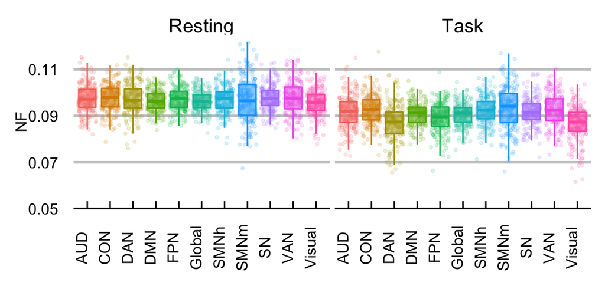

```r
sig_nfvar.list = networks

long = nfdata2[, c('Sub.ID','Age',paste('rs.',networks,sep=''),paste('task.',networks,sep=''))] %>%
    melt(.,id=c('Sub.ID','Age')) %>% rename(group=variable)
long$scan.condition = factor(unlist(lapply(long$group, function(x)strsplit(as.character(x),'[.]')[[1]][1])), levels=c('rs','task'),labels=c('Resting','Task'))
long$Network = unlist(lapply(long$group, function(x)strsplit(as.character(x),'[.]')[[1]][2]))
long$Network = gsub('_wocerebellum','',long$Network)

fig=ggplot(long, aes(x=Network, y=value, colour=Network, fill=Network)) +
  geom_boxplot(alpha=0.5, outlier.shape=NA) +
  geom_jitter(alpha=0.15,size=0.8) +
  facet_grid(.~scan.condition) +
  theme_economist_white(gray_bg = FALSE) +
  ylab("NF") + xlab('') +
  theme(legend.position="none",
        axis.text.x=element_text(size=11,angle = 90)) +
    scale_y_continuous(limits=c(0.05, 0.125), expand = c(0, 0))

fig
```

```r
png('Network_by_Scancondition_n187.png', width=2400, height=1200,res=300)
fig
dev.off()
```

```r
long$Network = relevel(factor(long$Network) , ref='Global')
tab_model(lmer(value ~ Network + (1|Sub.ID),long %>%
                 filter(scan.condition=='Resting')),
          lmer(value ~ Network + (1|Sub.ID),long %>%
                 filter(scan.condition=='Task')),
          show.std = TRUE,show.est = FALSE, dv.labels=c('Resting','taskfMRI'))
```

|  | Resting |  |  | taskfMRI |  |  |
| --- | --- | --- | --- | --- | --- | --- |
| Predictors | std. Beta | standardized CI | p | std. Beta | standardized CI | p |
| (Intercept) | -0.11 | -0.25 – 0.03 | **<0.001** | -0.04 | -0.17 – 0.10 | **<0.001** |
| Network [AUD] | 0.19 | 0.04 – 0.34 | **0.011** | 0.18 | 0.05 – 0.31 | **0.007** |
| Network [CON] | 0.21 | 0.07 – 0.36 | **0.004** | 0.30 | 0.16 – 0.43 | **<0.001** |
| Network [DAN] | 0.14 | -0.00 – 0.29 | 0.057 | -0.50 | -0.63 – -0.37 | **<0.001** |
| Network [DMN] | 0.01 | -0.13 – 0.16 | 0.866 | 0.05 | -0.08 – 0.18 | 0.458 |
| Network [FPN] | 0.15 | 0.01 – 0.30 | **0.042** | -0.18 | -0.31 – -0.04 | **0.009** |
| Network [SMNh] | 0.10 | -0.05 – 0.25 | 0.178 | 0.26 | 0.13 – 0.39 | **<0.001** |
| Network [SMNm] | 0.08 | -0.06 – 0.23 | 0.267 | 0.37 | 0.24 – 0.50 | **<0.001** |
| Network [SN] | 0.22 | 0.07 – 0.36 | **0.004** | 0.17 | 0.04 – 0.31 | **0.010** |
| Network [VAN] | 0.23 | 0.08 – 0.37 | **0.003** | 0.29 | 0.16 – 0.43 | **<0.001** |
| Network [Visual] | -0.12 | -0.27 – 0.03 | 0.117 | -0.56 | -0.69 – -0.43 | **<0.001** |
| Random Effects |  |  |  |  |  |  |
| σ<sup>2</sup> | 0.00 |  |  | 0.00 |  |  |
| τ<sub>00</sub> | 0.00 <sub>Sub.ID</sub> |  |  | 0.00 <sub>Sub.ID</sub> |  |  |
| ICC | 0.47 |  |  | 0.53 |  |  |
| N | 187 <sub>Sub.ID</sub> |  |  | 187 <sub>Sub.ID</sub> |  |  |
| Observations | 2057 |  |  | 2057 |  |  |
| Marginal R<sup>2</sup> / Conditional R<sup>2</sup> | 0.011 / 0.474 |  |  | 0.093 / 0.576 |  |  |

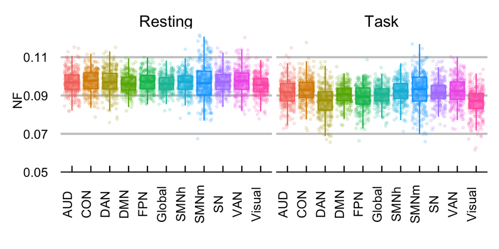

```r
long = X1.dat[, c('Sub.ID','Age',paste('rs.',networks,sep=''),paste('task.',networks,sep=''))] %>%
    melt(.,id=c('Sub.ID','Age')) %>% rename(group=variable) %>%
  filter(is.na(value)==FALSE)
long$scan.condition = factor(unlist(lapply(long$group, function(x)strsplit(as.character(x),'[.]')[[1]][1])), levels=c('rs','task'),labels=c('Resting','Task'))
long$Network = unlist(lapply(long$group, function(x)strsplit(as.character(x),'[.]')[[1]][2]))
long$Network = gsub('_wocerebellum','',long$Network)

fig=ggplot(long, aes(x=Network, y=value, colour=Network, fill=Network)) +
  geom_boxplot(alpha=0.5, outlier.shape=NA) +
  geom_jitter(alpha=0.15,size=0.8) +
  facet_grid(.~scan.condition) +
#  theme_minimal() +
  theme_economist_white(gray_bg = FALSE) +
  ylab("NF") + xlab('') +
  theme(legend.position="none",
        axis.text.x=element_text(size=11,angle = 90)) +
    scale_y_continuous(limits=c(0.05, 0.125), expand = c(0, 0))

fig
```

```r
png('Network_by_Scancondition_n386.png', width=2400, height=1200,res=300)
fig
dev.off()
```

```r
long$Network = relevel(factor(long$Network) , ref='Global')
tab_model(lmer(value ~ Network + (1|Sub.ID),long %>%
                 filter(scan.condition=='Resting')),
          lmer(value ~ Network + (1|Sub.ID),long %>%
                 filter(scan.condition=='Task')),
          show.std = TRUE,show.est = FALSE, dv.labels=c('Resting','taskfMRI'))
```

|  | Resting |  |  | taskfMRI |  |  |
| --- | --- | --- | --- | --- | --- | --- |
| Predictors | std. Beta | standardized CI | p | std. Beta | standardized CI | p |
| (Intercept) | -0.11 | -0.22 – 0.01 | **<0.001** | -0.05 | -0.16 – 0.06 | **<0.001** |
| Network [AUD] | 0.15 | 0.03 – 0.27 | **0.014** | 0.19 | 0.08 – 0.29 | **0.001** |
| Network [CON] | 0.20 | 0.08 – 0.32 | **0.001** | 0.35 | 0.25 – 0.46 | **<0.001** |
| Network [DAN] | 0.17 | 0.05 – 0.29 | **0.006** | -0.45 | -0.56 – -0.35 | **<0.001** |
| Network [DMN] | 0.02 | -0.10 – 0.14 | 0.758 | 0.04 | -0.07 – 0.14 | 0.485 |
| Network [FPN] | 0.14 | 0.02 – 0.26 | **0.022** | -0.16 | -0.26 – -0.05 | **0.004** |
| Network [SMNh] | 0.10 | -0.02 – 0.21 | 0.120 | 0.27 | 0.17 – 0.38 | **<0.001** |
| Network [SMNm] | 0.10 | -0.02 – 0.22 | 0.099 | 0.36 | 0.25 – 0.46 | **<0.001** |
| Network [SN] | 0.21 | 0.09 – 0.33 | **0.001** | 0.18 | 0.07 – 0.28 | **0.001** |
| Network [VAN] | 0.23 | 0.11 – 0.35 | **<0.001** | 0.30 | 0.19 – 0.41 | **<0.001** |
| Network [Visual] | -0.14 | -0.26 – -0.02 | **0.023** | -0.53 | -0.64 – -0.43 | **<0.001** |
| Random Effects |  |  |  |  |  |  |
| σ<sup>2</sup> | 0.00 |  |  | 0.00 |  |  |
| τ<sub>00</sub> | 0.00 <sub>Sub.ID</sub> |  |  | 0.00 <sub>Sub.ID</sub> |  |  |
| ICC | 0.47 |  |  | 0.53 |  |  |
| N | 279 <sub>Sub.ID</sub> |  |  | 294 <sub>Sub.ID</sub> |  |  |
| Observations | 3069 |  |  | 3234 |  |  |
| Marginal R<sup>2</sup> / Conditional R<sup>2</sup> | 0.011 / 0.480 |  |  | 0.088 / 0.568 |  |  |

# Reviewer’s Request

## Standardized regression coefficients between age and cognition

```r
cogvar.list = names(X1.dat)[c(7:10,6,12,17)]

xvar='Age'
tab2=do.call(rbind,lapply(cogvar.list, function(x){
  eval(parse(text=paste('fit<-lm(scale(',x,')~ scale(',xvar,'),X1.dat %>% filter(is.na(',x,')==FALSE & is.na(',xvar,')==FALSE))')))
  tmp=summary(fit)$coefficients
  re=data.frame(yvar=x, xvar=xvar,beta=tmp[,1], CI95=confint(fit),pval=tmp[,4])
  rownames(re)<-NULL
  return(re[2,])
  }))  %>%
  mutate(p.adjust=p.adjust(pval,method='BH'))

tab2%>%
#  filter(pval<0.05) %>%
  mutate(sig = paste(ifelse(pval<0.05,ifelse(pval<0.01, ifelse(pval<0.001,'***','**'),'*'),''),
         ifelse(p.adjust<0.05,'+',''),sep='')) %>%
  mutate(text = paste('[',round(CI95.2.5..,3), ',',round(CI95.97.5..,3),']',sig,sep='')) %>%
  dplyr::select(yvar, beta,text)%>%
  kable(.,full=F,digit=3) %>%
  kable_classic(.)
```

|  | yvar | beta | text |
| --- | --- | --- | --- |
| 2 | NPSpeed_attention | -0.549 | [-0.633,-0.465]***+ |
| 21 | NPReasoning | -0.449 | [-0.539,-0.359]***+ |
| 22 | NPMemory | -0.444 | [-0.534,-0.354]***+ |
| 23 | NPVocab | 0.291 | [0.195,0.387]***+ |
| 24 | WAIS3matRAW | -0.382 | [-0.475,-0.289]***+ |
| 25 | MatReas_NumCor | -0.432 | [-0.532,-0.332]***+ |
| 26 | MatReas_medianCorRT.log | 0.235 | [0.127,0.343]***+ |

## Network matric

- Used the threshold of 10 to control multiple comparison..

```r
nm = X1.dat %>%
  left_join(.,
            readxl::read_xlsx('/Volumes/promise_p/CRRANN/derivatives/NetworkData/BC_PC.xlsx') %>%
              select(-Eligibility) %>%
              rename(Sub.ID=ID)) %>%
  left_join(.,
            readxl::read_xlsx('/Volumes/promise_p/CRRANN/derivatives/NetworkData/BC_PC.xlsx', sheet='MR_BC_PC') %>%
              select(-Eligibility) %>%
              rename(Sub.ID=ID))
nm.list = names(nm)[grep('10',names(nm))]
```

### 1. Association with Age

```r
xvar='Age'
tab2=do.call(rbind,lapply(nm.list, function(x){
  eval(parse(text=paste('fit<-lm(scale(',x,')~ scale(',xvar,'),nm %>% filter(is.na(',x,')==FALSE & is.na(',xvar,')==FALSE))')))
  tmp=summary(fit)$coefficients
  re=data.frame(yvar=x, xvar=xvar,beta=tmp[,1], CI95=confint(fit),pval=tmp[,4])
  rownames(re)<-NULL
  return(re[2,])
  }))  %>%
  mutate(p.adjust=p.adjust(pval,method='BH'))

tab2%>%
#  filter(pval<0.05) %>%
  mutate(sig = paste(ifelse(pval<0.05,ifelse(pval<0.01, ifelse(pval<0.001,'***','**'),'*'),''),
         ifelse(p.adjust<0.05,'+',''),sep='')) %>%
  mutate(text = paste('[',round(CI95.2.5..,3), ',',round(CI95.97.5..,3),']',sig,sep='')) %>%
  dplyr::select(yvar, beta,text)%>%
  kable(.,full=F,digit=3) %>%
  kable_classic(.)
```

|  | yvar | beta | text |
| --- | --- | --- | --- |
| 2 | Aud_RS_BC10 | 0.014 | [-0.088,0.116] |
| 21 | CON_RS_BC10 | 0.117 | [0.015,0.218]* |
| 22 | DAN_RS_BC10 | 0.056 | [-0.046,0.158] |
| 23 | DMN_RS_BC10 | -0.013 | [-0.115,0.089] |
| 24 | FPN_RS_BC10 | -0.077 | [-0.179,0.025] |
| 25 | SMh_RS_BC10 | 0.016 | [-0.086,0.118] |
| 26 | SMm_RS_BC10 | -0.029 | [-0.131,0.073] |
| 27 | SN_RS_BC10 | -0.031 | [-0.133,0.071] |
| 28 | VAN_RS_BC10 | 0.020 | [-0.082,0.122] |
| 29 | Vis_RS_BC10 | -0.082 | [-0.184,0.02] |
| 210 | Global_RS_BC10 | -0.026 | [-0.129,0.076] |
| 211 | Aud_RS_PC10 | 0.059 | [-0.043,0.161] |
| 212 | CON_RS_PC10 | 0.048 | [-0.054,0.15] |
| 213 | DAN_RS_PC10 | 0.006 | [-0.096,0.108] |
| 214 | DMN_RS_PC10 | 0.073 | [-0.028,0.175] |
| 215 | FPN_RS_PC10 | 0.123 | [0.022,0.224]* |
| 216 | SMh_RS_PC10 | 0.037 | [-0.065,0.139] |
| 217 | SMm_RS_PC10 | 0.072 | [-0.03,0.174] |
| 218 | SN_RS_PC10 | 0.065 | [-0.037,0.167] |
| 219 | VAN_RS_PC10 | 0.051 | [-0.051,0.153] |
| 220 | Vis_RS_PC10 | 0.049 | [-0.053,0.151] |
| 221 | Global_RS_PC10 | 0.082 | [-0.02,0.184] |
| 222 | Aud_MR_BC10 | 0.129 | [0.019,0.239]* |
| 223 | CON_MR_BC10 | -0.016 | [-0.127,0.095] |
| 224 | DAN_MR_BC10 | 0.042 | [-0.068,0.153] |
| 225 | DMN_MR_BC10 | 0.049 | [-0.061,0.16] |
| 226 | FPN_MR_BC10 | 0.060 | [-0.051,0.17] |
| 227 | SMh_MR_BC10 | -0.056 | [-0.166,0.055] |
| 228 | SMm_MR_BC10 | 0.040 | [-0.071,0.15] |
| 229 | SN_MR_BC10 | -0.060 | [-0.171,0.05] |
| 230 | VAN_MR_BC10 | 0.016 | [-0.095,0.126] |
| 231 | Vis_MR_BC10 | 0.012 | [-0.099,0.123] |
| 232 | Global_MR_BC10 | 0.031 | [-0.08,0.141] |
| 233 | Aud_MR_PC10 | 0.121 | [0.011,0.23]* |
| 234 | CON_MR_PC10 | 0.098 | [-0.012,0.208] |
| 235 | DAN_MR_PC10 | 0.198 | [0.09,0.307]***+ |
| 236 | DMN_MR_PC10 | 0.081 | [-0.029,0.192] |
| 237 | FPN_MR_PC10 | 0.234 | [0.127,0.342]***+ |
| 238 | SMh_MR_PC10 | 0.135 | [0.025,0.244]* |
| 239 | SMm_MR_PC10 | 0.088 | [-0.022,0.199] |
| 240 | SN_MR_PC10 | 0.135 | [0.025,0.244]* |
| 241 | VAN_MR_PC10 | 0.086 | [-0.024,0.196] |
| 242 | Vis_MR_PC10 | 0.253 | [0.145,0.36]***+ |
| 243 | Global_MR_PC10 | 0.185 | [0.076,0.293]***+ |

### 2. Association with cognition controlling for age, education and sex

```r
do.call(rbind, lapply( cogvar.list, function(yvar){
do.call(rbind,lapply(nm.list, function(xvar){
  eval(parse(text=paste('fit<-lm(scale(',yvar,')~ scale(',xvar,') + Age + Gender + Education,nm %>% filter(is.na(',xvar,')==FALSE & is.na(',yvar,')==FALSE))')))
  tmp=summary(fit)$coefficients
  re=data.frame(xvar=xvar, yvar=yvar,beta=tmp[,1], CI95=confint(fit),pval=tmp[,4])
  rownames(re)<-NULL
  return(re[2,])
  }))}))  %>%
  mutate(p.adjust=p.adjust(pval,method='BH')) %>%
  mutate(sig = paste(ifelse(pval<0.05,ifelse(pval<0.01, ifelse(pval<0.001,'***','**'),'*'),''),
         ifelse(p.adjust<0.05,'+',''),sep='')) %>%
  filter(pval<0.05) %>%
  mutate(text = paste('[',round(CI95.2.5..,3), ',',round(CI95.97.5..,3),']',sig,sep='')) %>%
  dplyr::select(yvar,xvar, beta,text) %>%
  kable(.,full=F,digit=3) %>%
  kable_classic(.)
```

|  | yvar | xvar | beta | text |
| --- | --- | --- | --- | --- |
| 27 | NPSpeed_attention | SN_RS_BC10 | -0.090 | [-0.174,-0.005]* |
| 224 | NPSpeed_attention | DAN_MR_BC10 | -0.099 | [-0.19,-0.008]* |
| 232 | NPSpeed_attention | Global_MR_BC10 | -0.097 | [-0.188,-0.007]* |
| 234 | NPSpeed_attention | CON_MR_PC10 | -0.117 | [-0.209,-0.026]* |
| 235 | NPSpeed_attention | DAN_MR_PC10 | -0.142 | [-0.234,-0.049]** |
| 237 | NPSpeed_attention | FPN_MR_PC10 | -0.102 | [-0.196,-0.008]* |
| 238 | NPSpeed_attention | SMh_MR_PC10 | -0.119 | [-0.211,-0.027]* |
| 240 | NPSpeed_attention | SN_MR_PC10 | -0.111 | [-0.202,-0.019]* |
| 241 | NPSpeed_attention | VAN_MR_PC10 | -0.139 | [-0.23,-0.048]** |
| 243 | NPSpeed_attention | Global_MR_PC10 | -0.126 | [-0.218,-0.033]** |
| 2241 | NPReasoning | DAN_MR_BC10 | -0.129 | [-0.223,-0.035]** |
| 2351 | NPReasoning | DAN_MR_PC10 | -0.126 | [-0.223,-0.029]* |
| 2361 | NPReasoning | DMN_MR_PC10 | -0.130 | [-0.225,-0.035]** |
| 2381 | NPReasoning | SMh_MR_PC10 | -0.119 | [-0.215,-0.023]* |
| 2411 | NPReasoning | VAN_MR_PC10 | -0.142 | [-0.236,-0.047]** |
| 2421 | NPReasoning | Vis_MR_PC10 | -0.106 | [-0.205,-0.008]* |
| 2431 | NPReasoning | Global_MR_PC10 | -0.132 | [-0.228,-0.036]** |
| 2102 | NPMemory | Global_RS_BC10 | 0.159 | [0.069,0.249]***+ |
| 2292 | NPMemory | SN_MR_BC10 | 0.110 | [0.013,0.206]* |
| 2342 | NPMemory | CON_MR_PC10 | -0.099 | [-0.196,-0.002]* |
| 2372 | NPMemory | FPN_MR_PC10 | -0.112 | [-0.211,-0.012]* |
| 2412 | NPMemory | VAN_MR_PC10 | -0.126 | [-0.223,-0.029]* |
| 248 | NPVocab | Aud_RS_BC10 | 0.108 | [0.018,0.199]* |
| 2243 | NPVocab | DAN_MR_BC10 | -0.136 | [-0.233,-0.039]** |
| 2363 | NPVocab | DMN_MR_PC10 | -0.124 | [-0.222,-0.027]* |
| 2373 | NPVocab | FPN_MR_PC10 | -0.104 | [-0.204,-0.003]* |
| 2413 | NPVocab | VAN_MR_PC10 | -0.142 | [-0.239,-0.044]** |
| 2433 | NPVocab | Global_MR_PC10 | -0.109 | [-0.209,-0.01]* |
| 2244 | WAIS3matRAW | DAN_MR_BC10 | -0.153 | [-0.253,-0.053]** |
| 2354 | WAIS3matRAW | DAN_MR_PC10 | -0.120 | [-0.224,-0.017]* |
| 2364 | WAIS3matRAW | DMN_MR_PC10 | -0.110 | [-0.212,-0.009]* |
| 2414 | WAIS3matRAW | VAN_MR_PC10 | -0.111 | [-0.212,-0.009]* |
| 2434 | WAIS3matRAW | Global_MR_PC10 | -0.113 | [-0.216,-0.01]* |
| 2218 | MatReas_NumCor | DAN_RS_BC10 | -0.137 | [-0.236,-0.039]** |
| 2245 | MatReas_NumCor | DAN_MR_BC10 | -0.101 | [-0.198,-0.003]* |
| 2255 | MatReas_NumCor | DMN_MR_BC10 | 0.136 | [0.038,0.234]** |
| 2265 | MatReas_NumCor | FPN_MR_BC10 | -0.113 | [-0.21,-0.015]* |
| 2335 | MatReas_NumCor | Aud_MR_PC10 | -0.130 | [-0.228,-0.032]** |
| 2345 | MatReas_NumCor | CON_MR_PC10 | -0.120 | [-0.218,-0.022]* |
| 2355 | MatReas_NumCor | DAN_MR_PC10 | -0.170 | [-0.269,-0.071]***+ |
| 2365 | MatReas_NumCor | DMN_MR_PC10 | -0.136 | [-0.234,-0.039]** |
| 2375 | MatReas_NumCor | FPN_MR_PC10 | -0.147 | [-0.247,-0.046]** |
| 2385 | MatReas_NumCor | SMh_MR_PC10 | -0.135 | [-0.234,-0.037]** |
| 2416 | MatReas_NumCor | VAN_MR_PC10 | -0.151 | [-0.248,-0.053]** |
| 2425 | MatReas_NumCor | Vis_MR_PC10 | -0.147 | [-0.248,-0.046]** |
| 2435 | MatReas_NumCor | Global_MR_PC10 | -0.155 | [-0.254,-0.056]** |
| 2326 | MatReas_medianCorRT.log | Global_MR_BC10 | -0.142 | [-0.25,-0.035]** |
| 2336 | MatReas_medianCorRT.log | Aud_MR_PC10 | -0.141 | [-0.249,-0.032]* |
| 2346 | MatReas_medianCorRT.log | CON_MR_PC10 | -0.193 | [-0.3,-0.086]***+ |
| 2356 | MatReas_medianCorRT.log | DAN_MR_PC10 | -0.191 | [-0.301,-0.082]***+ |
| 2366 | MatReas_medianCorRT.log | DMN_MR_PC10 | -0.183 | [-0.29,-0.075]***+ |
| 2376 | MatReas_medianCorRT.log | FPN_MR_PC10 | -0.232 | [-0.342,-0.123]***+ |
| 2386 | MatReas_medianCorRT.log | SMh_MR_PC10 | -0.194 | [-0.303,-0.086]***+ |
| 2396 | MatReas_medianCorRT.log | SMm_MR_PC10 | -0.154 | [-0.262,-0.046]** |
| 2406 | MatReas_medianCorRT.log | SN_MR_PC10 | -0.179 | [-0.287,-0.07]**+ |
| 2418 | MatReas_medianCorRT.log | VAN_MR_PC10 | -0.197 | [-0.304,-0.09]***+ |
| 2426 | MatReas_medianCorRT.log | Vis_MR_PC10 | -0.135 | [-0.247,-0.023]* |
| 2436 | MatReas_medianCorRT.log | Global_MR_PC10 | -0.218 | [-0.326,-0.11]***+ |

### 3. Moderation of cognitive aging

```r
do.call(rbind, lapply( cogvar.list, function(yvar){
do.call(rbind,lapply(nm.list, function(xvar){
  eval(parse(text=paste('fit<-lm(scale(',yvar,')~ scale(',xvar,') * scale(Age) + Gender + Education,nm %>% filter(is.na(',xvar,')==FALSE & is.na(',yvar,')==FALSE))')))
  tmp=summary(fit)$coefficients
  re=data.frame(xvar=xvar, yvar=yvar,beta=tmp[,1], CI95=confint(fit),pval=tmp[,4])
  rownames(re)<-NULL
  return(re[6,])
  }))}))  %>%
  mutate(p.adjust=p.adjust(pval,method='BH')) %>%
  mutate(sig = paste(ifelse(pval<0.05,ifelse(pval<0.01, ifelse(pval<0.001,'***','**'),'*'),''),
         ifelse(p.adjust<0.05,'+',''),sep='')) %>%
  filter(pval<0.05) %>%
  mutate(text = paste('[',round(CI95.2.5..,3), ',',round(CI95.97.5..,3),']',sig,sep='')) %>%
  dplyr::select(yvar,xvar, beta,text) %>%
  kable(.,full=F,digit=3) %>%
  kable_classic(.)
```

|  | yvar | xvar | beta | text |
| --- | --- | --- | --- | --- |
| 6210 | NPReasoning | DAN_RS_BC10 | -0.116 | [-0.206,-0.025]* |
| 682 | NPMemory | VAN_RS_BC10 | -0.121 | [-0.211,-0.031]** |
| 6223 | NPVocab | Aud_MR_BC10 | 0.117 | [0.019,0.214]* |
| 6104 | WAIS3matRAW | Global_RS_BC10 | -0.123 | [-0.216,-0.031]** |
| 6224 | WAIS3matRAW | Aud_MR_BC10 | 0.119 | [0.018,0.221]* |
| 6118 | MatReas_NumCor | CON_RS_BC10 | 0.110 | [0.006,0.213]* |
| 6218 | MatReas_NumCor | DAN_RS_BC10 | -0.104 | [-0.207,-0.001]* |
| 6265 | MatReas_NumCor | FPN_MR_BC10 | 0.114 | [0.022,0.206]* |

### 4. Network matric difference between resting and task session

```r
nwlist = c('Aud','CON','DAN','DMN','FPN','SMh','SMm','SN','VAN','Vis','Global')

for (thresh in c(5,10,15,20)){
  for (j in nwlist){
    eval(parse(text=paste('nm$chng.', j ,'_BC',thresh,'= NA',sep='')))
    eval(parse(text=paste('nm$chng.', j, '_BC',thresh,'=nm$',j,'_MR_BC',thresh,'-nm$',j,'_RS_BC',thresh,sep='')))
    eval(parse(text=paste('nm$chng.', j ,'_PC',thresh,'= NA',sep='')))
    eval(parse(text=paste('nm$chng.', j, '_PC',thresh,'=nm$',j,'_MR_PC',thresh,'-nm$',j,'_RS_PC',thresh,sep='')))
  }
  }

networks.list=c( paste('chng.',nwlist,'_BC10', sep=''),paste('chng.',nwlist,'_BC10', sep=''))

thresh=10
nm2 = nm %>%
  filter(img_group=='Both')

do.call(rbind,lapply(c('BC','PC'), function(method){
  do.call(rbind, lapply(nwlist,function(j){
    eval(parse(text=paste('fit=t.test(nm2$',j,'_MR_',method,thresh,',nm2$',j,'_RS_',method,thresh,',paired=TRUE)',sep='')))
    eval(parse(text=paste('ds=effectsize::cohens_d(nm2$',j,'_MR_',method,thresh,',nm2$',j,'_RS_',method,thresh,',paired=TRUE)',sep='')))

    a = (data.frame(networks=j,method=method,diff=fit$estimate,lci=fit$conf.int[1],uci=fit$conf.int[2],
               t=fit$statistic,df=fit$parameter,pvalue=fit$p.value,data.frame(ds)))
    return(a)
    }))})) %>%
  dplyr::select(-CI) %>%
  mutate(p.adjust=p.adjust(pvalue, method='BH')) %>%
  mutate(sig = paste(ifelse(pvalue<0.05,
                             ifelse(pvalue<0.01,
                                    ifelse(pvalue<0.001,'***','**'),'*'),''),
                     ifelse(p.adjust<0.05,'+',''),sep='')) %>%
  mutate(text=paste('[',round(lci,3),',',round(uci,3),']', sig))  %>%
  select(networks, method,diff, text,Cohens_d) %>%
  kable(., digits=3) %>%
  kable_classic(.)
```

|  | networks | method | diff | text | Cohens_d |
| --- | --- | --- | --- | --- | --- |
| mean of the differences | Aud | BC | 6.428 | [ -10.545 , 23.4 ] | 0.055 |
| mean of the differences1 | CON | BC | 33.298 | [ 17.771 , 48.825 ] ***+ | 0.310 |
| mean of the differences2 | DAN | BC | -47.638 | [ -65.359 , -29.918 ] ***+ | -0.389 |
| mean of the differences3 | DMN | BC | 8.209 | [ 0.606 , 15.812 ] *+ | 0.156 |
| mean of the differences4 | FPN | BC | -39.306 | [ -51.437 , -27.174 ] ***+ | -0.469 |
| mean of the differences5 | SMh | BC | 18.006 | [ 5.479 , 30.533 ] **+ | 0.208 |
| mean of the differences6 | SMm | BC | 26.946 | [ -1.869 , 55.762 ] | 0.135 |
| mean of the differences7 | SN | BC | 7.053 | [ -7.121 , 21.227 ] | 0.072 |
| mean of the differences8 | VAN | BC | 31.114 | [ 12.137 , 50.09 ] **+ | 0.237 |
| mean of the differences9 | Vis | BC | -30.754 | [ -41.578 , -19.931 ] ***+ | -0.411 |
| mean of the differences10 | Global | BC | 1.735 | [ 0.663 , 2.806 ] **+ | 0.234 |
| mean of the differences11 | Aud | PC | -0.104 | [ -0.125 , -0.083 ] ***+ | -0.720 |
| mean of the differences12 | CON | PC | -0.091 | [ -0.111 , -0.071 ] ***+ | -0.664 |
| mean of the differences21 | DAN | PC | -0.149 | [ -0.171 , -0.127 ] ***+ | -0.983 |
| mean of the differences31 | DMN | PC | -0.094 | [ -0.111 , -0.077 ] ***+ | -0.805 |
| mean of the differences41 | FPN | PC | -0.114 | [ -0.133 , -0.095 ] ***+ | -0.868 |
| mean of the differences51 | SMh | PC | -0.094 | [ -0.114 , -0.074 ] ***+ | -0.687 |
| mean of the differences61 | SMm | PC | -0.114 | [ -0.14 , -0.089 ] ***+ | -0.644 |
| mean of the differences71 | SN | PC | -0.092 | [ -0.112 , -0.072 ] ***+ | -0.679 |
| mean of the differences81 | VAN | PC | -0.102 | [ -0.124 , -0.081 ] ***+ | -0.684 |
| mean of the differences91 | Vis | PC | -0.134 | [ -0.152 , -0.116 ] ***+ | -1.083 |
| mean of the differences101 | Global | PC | -0.102 | [ -0.118 , -0.087 ] ***+ | -0.949 |

- Variance comparison between resting and task

```r
bb=lapply(c('BC','PC'), function(method){
  re=do.call(rbind, lapply(nwlist,function(j){
    mycol=paste(j,c('_MR_','_RS_'),method,thresh,sep='')
    tmpdat = nm2[,c('Sub.ID',mycol)] %>%
      melt(.,id='Sub.ID') %>%
      mutate(variable=factor(variable,levels=paste(j,c('_RS_','_MR_'),method,thresh,sep='')))
    vardesc=tmpdat %>% group_by(variable) %>% summarise(sd = sd(value, na.rm=TRUE)) %>%
      mutate(variable=gsub(j,'',variable)) %>% reshape2::dcast(., .~variable,mean)
    fit=var.test(value ~ variable, tmpdat,alternative="two.sided")

    a = (data.frame(networks=j,method=method,vardesc[,-1],var.ratio = fit$estimate, ci=t(fit$conf.int),f=fit$statistic,df=t(fit$parameter),pvalue=fit$p.value))
    return(a)
    }))
  row.names(re)<-c()
  return(re)})
names(bb[[2]])<-names(bb[[1]])
do.call(rbind, bb)%>%
  mutate(p.adjust=p.adjust(pvalue, method='BH')) %>%
  mutate(sig = paste(ifelse(pvalue<0.05,
                             ifelse(pvalue<0.01,
                                    ifelse(pvalue<0.001,'***','**'),'*'),''),
                     ifelse(p.adjust<0.05,'+',''),sep='')) %>%
  mutate(text=paste('[',round(ci.1,3),',',round(ci.2,3),']', sig))  %>%
  select(networks, contains('X_'),   var.ratio,text)%>%
  kable(., digits=4) %>%
  kable_classic(.)
```

| networks | X_MR_BC10 | X_RS_BC10 | var.ratio | text |
| --- | --- | --- | --- | --- |
| Aud | 93.5918 | 76.3523 | 0.6655 | [ 0.499 , 0.888 ] **+ |
| CON | 84.2817 | 79.6183 | 0.8924 | [ 0.669 , 1.191 ] |
| DAN | 90.4807 | 78.0701 | 0.7445 | [ 0.558 , 0.994 ] * |
| DMN | 40.3339 | 38.2319 | 0.8985 | [ 0.673 , 1.199 ] |
| FPN | 62.5507 | 55.8251 | 0.7965 | [ 0.597 , 1.063 ] |
| SMh | 70.3315 | 56.1246 | 0.6368 | [ 0.477 , 0.85 ] **+ |
| SMm | 158.8168 | 142.3783 | 0.8037 | [ 0.602 , 1.073 ] |
| SN | 71.7257 | 62.6590 | 0.7632 | [ 0.572 , 1.019 ] |
| VAN | 101.4628 | 86.2412 | 0.7225 | [ 0.541 , 0.964 ] * |
| Vis | 58.4991 | 55.7769 | 0.9091 | [ 0.681 , 1.213 ] |
| Global | 3.0279 | 7.0278 | 5.3872 | [ 4.037 , 7.191 ] ***+ |
| Aud | 0.1106 | 0.0957 | 0.7484 | [ 0.561 , 0.999 ] * |
| CON | 0.1051 | 0.0983 | 0.8747 | [ 0.655 , 1.168 ] |
| DAN | 0.1092 | 0.0984 | 0.8128 | [ 0.609 , 1.085 ] |
| DMN | 0.0836 | 0.0811 | 0.9402 | [ 0.704 , 1.255 ] |
| FPN | 0.0984 | 0.0940 | 0.9133 | [ 0.684 , 1.219 ] |
| SMh | 0.0992 | 0.0988 | 0.9903 | [ 0.742 , 1.322 ] |
| SMm | 0.1405 | 0.1202 | 0.7314 | [ 0.548 , 0.976 ] * |
| SN | 0.0964 | 0.0967 | 1.0046 | [ 0.753 , 1.341 ] |
| VAN | 0.1143 | 0.0992 | 0.7538 | [ 0.565 , 1.006 ] |
| Vis | 0.0934 | 0.0915 | 0.9585 | [ 0.718 , 1.279 ] |
| Global | 0.0794 | 0.0754 | 0.9012 | [ 0.675 , 1.203 ] |